# Executions in the US

22 August, 2019

## Intro - The Exploratory Data Analysis Cycle

Hi all! Welcome to our first live-coding session!

Before we get started, I should warn you: I’m a pretty fast typist. **Don’t try to keep up with my narration here!** There’s no need, since I’ll share this document with you after class.

Instead, **do** try to keep up with the code! We’ll take it slow; I promise I won’t leave anyone behind! Of course, the document that you’re authoring along with me will be yours personally. Use it as you wish, and write whatever you want in it!

One more warning: since this is your first time coding, there will be lots you don’t understand. That’s ok! With practice, you’ll start to understand the logic. Don’t overwhelm yourself trying to memorize everyting. Let’s just play the game together – I’ll show you what the right moves are.

So, let’s get going! First things first: we need to get our tools out! Computer programmers call them “libraries”.

```r
#This is our toolkit: The Tidyverse!
library(tidyverse)

#This library makes our graphs pretty.  There are many options.
library(ggthemes)
theme_set(theme_tufte()+theme(text=element_text(family="sans")))
```

The code above loaded the “tidyverse” package. Cool! But, we still need some actual data to work on.

```r
exData <- read_csv("death penalty data.csv")
```

We’ve got data! But… now what? The awesome and terrifying answer is: **it’s up to us!** The process is called “Exploratory Data Analyis”, or EDA for short. It involves three stages:

1. **Ask questions** about your dataset. What are you interested in? What varibles catch your eye? Are there relationships between variables? Find some summary statistics, make some visuals. Here, inspiration follows from perspiration - try things out! Play around and be creative!
2. **Analyze**. What conclusions can you draw from your explorations? What could explain the qualities and trends that you see?
3. **Communicate.** What results are worthy of sharing? How would you like your audience to engage with them? Should some sort of action be taken? What further study is needed?

Allright, let’s jump in. When I look at this data, it seems that age, sex, and race all deserve some attention.

## Key Variables: Age, Sex, and Race

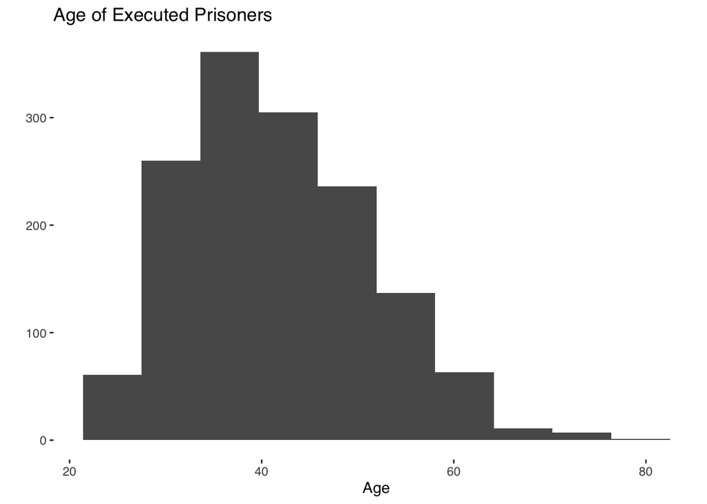

```r
#Let's look at a histogram:
qplot(Age, bins=10, data=exData,
      main="Age of Executed Prisoners")
```

```r
#And, let's see the stats:
summary(exData$Age)
```

```
##    Min. 1st Qu.  Median    Mean 3rd Qu.    Max.
##   22.00   34.00   40.00   41.48   47.00   77.00
```

Now, let’s take a look at the gender of executed prisoners.

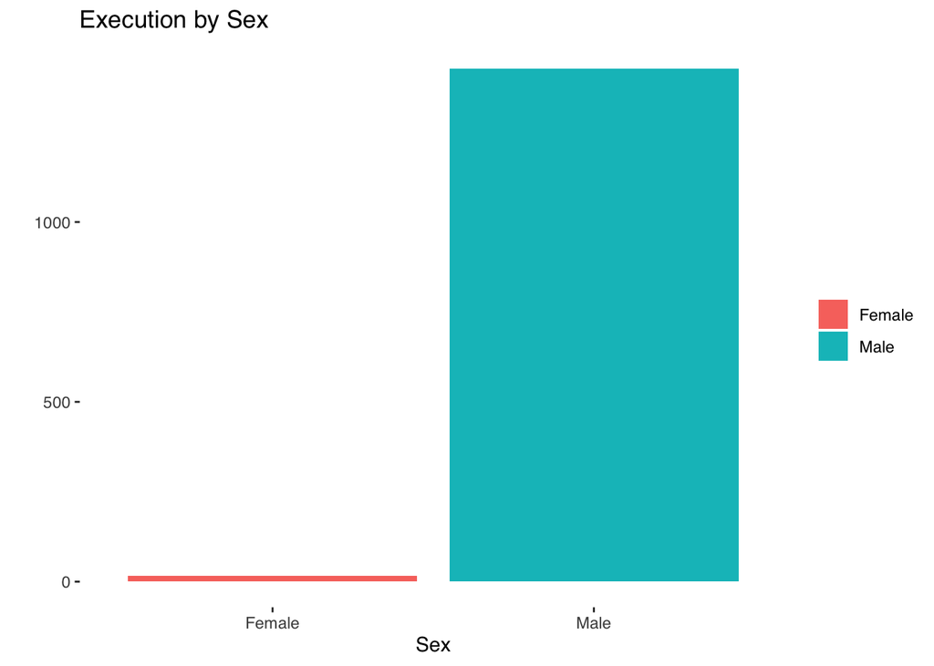

```r
#Let's look at a histogram:
qplot(Sex, fill=Sex, data=exData,
      main="Execution by Sex") + theme(legend.title = element_blank())
```

Woah, not many women. Let’s look at those numbers: there are 16 women out of 1442 total executions, so 1.10957% of all prisoners executed are women. I make two conclusions from this:

1. Almost all executed prisoners are men.
2. It’s going to be hard to draw conclusions about the women, since n=16 is a very small sample size.

In light of these observations, my intuition is to focus only on male prisoners. Finally, let’s look at race.

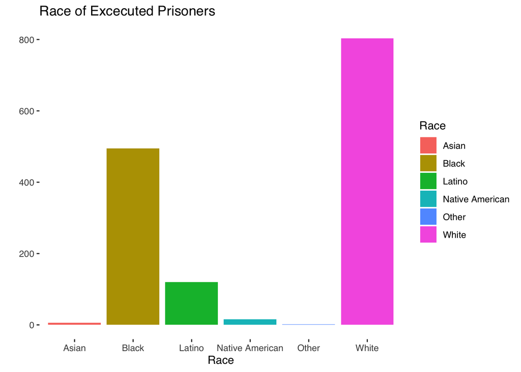

```r
## Fancy Footwork Alert!  "Native American" is very long, messing up graphics
levels(exData$Race)[levels(exData$Race)=="Native American"] <- "N.A."

#Make a bar plot:
qplot(Race, fill=Race, data=exData,
      main = "Race of Excecuted Prisoners")
```

Looks like most of the prisoners were white, with black prisoners close behind. Does this mean it’s more likely for a white person to be executed? What issues might we be ignoring?

[waits for the audience]

That’s right, these are **counts**, not **percentages**! That’s important, because black Americans are only about 12% of the population. This dataset doesn’t contain information about US population and demographics for the years recorded, so we’d have to look at a different dataset if we wanted to follow-up on this.

## Executions Over Time

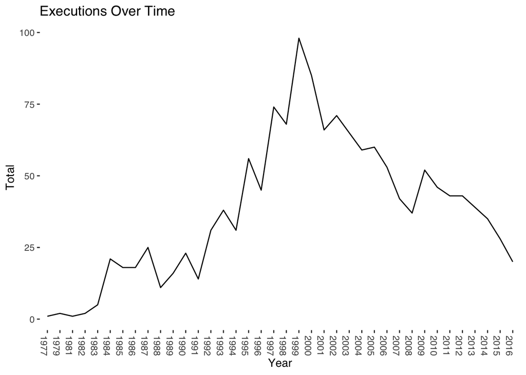

```r
######### ALERT:  Fancy Footwork Below!  Dont' stress about the details.


#Explain the date format to R
exData$Date <- as.Date(exData$Date, format="%m/%d/%Y")

#Add a "Year" column for easy reference
exData <- mutate(exData, Year = format(exData$Date, "%Y"))

#Shortcut to angle axis labels
angle_x_axis <- theme(axis.text.x = element_text(angle = -90))

#Count the total number of executions in each year
yearSummary <- exData %>%
  group_by(Year) %>%
  summarize(Total = n())

########## Fancy footwork is over!


qplot(Year, Total, group=1, geom="line", data=yearSummary,
      main="Executions Over Time") +
      angle_x_axis
```

Wow! This graph is teeming with narrative! What’s the story here? Why did executions build up to a crecendo in y2k, then taper off? Certainly there must be some event or policy change or … something?? We’ll need to look outside this dataset for the answers… but now we know what we’re looking for!

## Executions by State

We have an idea about *when* executions are happening; what about *where*?

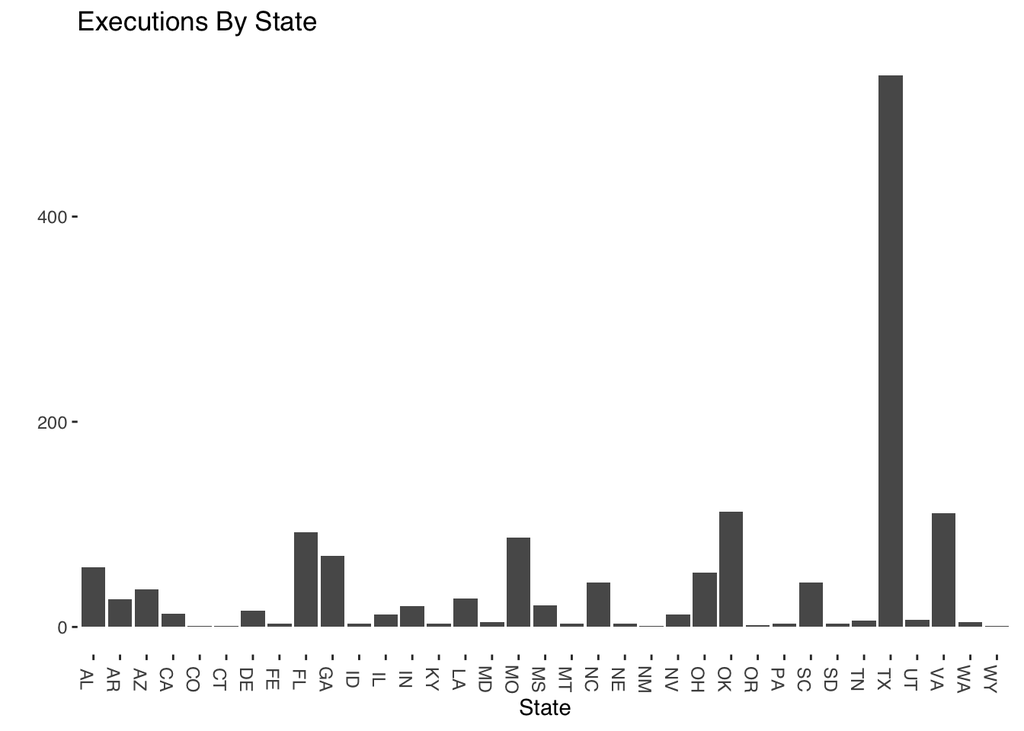

```r
qplot(State, data=exData,
      main = "Executions By State")+
      angle_x_axis
```

Um… Damn, Texas. That’s one big phallic bar of death. Takeaways:

1. The death penalty is really only an issue in a dozen or so states. Maybe we can take a closer look at those staes? Let’s take a look at the race distribution in each state:

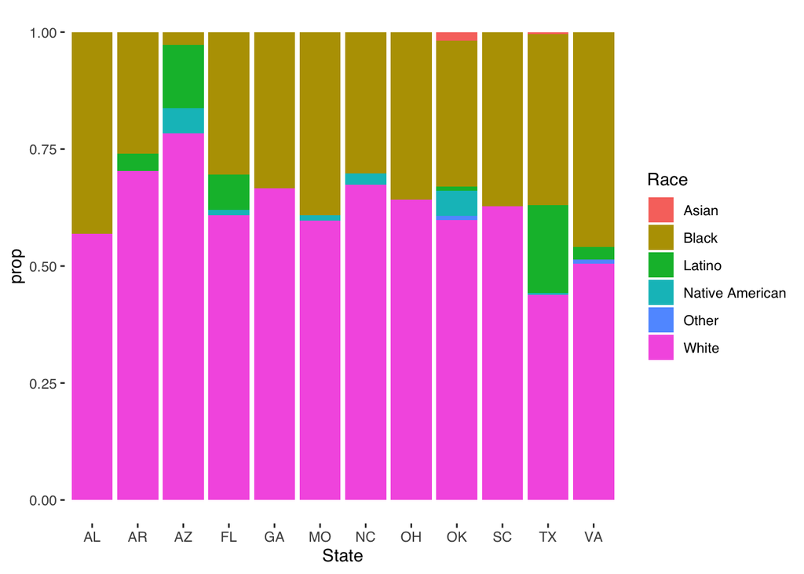

```r
dirtyDozen <- exData %>%
  filter(State == "AL" | State == "AZ" | State == "FL" |
         State == "GA" | State == "MO" | State == "OK" |
         State == "VA" | State == "NC" | State == "OH" |
         State == "TX" | State == "AR" | State == "SC")

#deathStates$Race <- as.factor(deathStates$Race)

dirtyRaceDist <- count(dirtyDozen, Method, State, Race) %>%
        group_by(State) %>%
        mutate(prop=n/sum(n))

qplot(State, prop, fill=Race, data=dirtyRaceDist, geom="col")
```

```r
#proportions <- data.frame(table(dirtyDozen$State)/nrow(dirtyDozen))



#dirtyDozen <- right_join(dirtyDozen, proportions, by=c("State"="Var1"))



#qplot(State, geom="bar", weight=1/Freq , fill=Race, data=dirtyDozen)+
#  angle_x_axis
```

Another visualization of the same data:

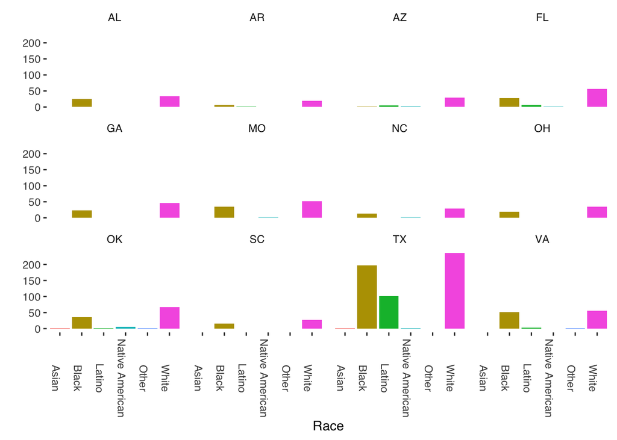

```r
qplot(Race, geom="bar", data=dirtyDozen, fill=dirtyDozen$Race,
      facets = ~dirtyDozen$State)+
      angle_x_axis+
      theme(legend.position = "none")
```

Lastly, let’s look at race over time:

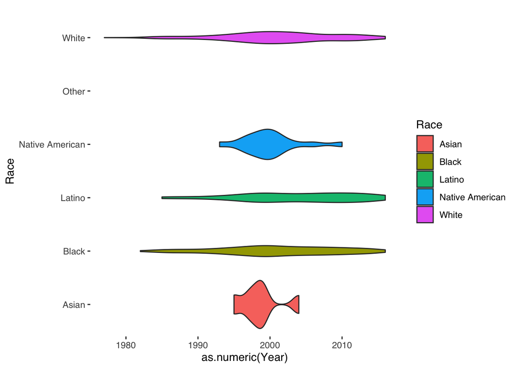

```r
qplot(Race, as.numeric(Year), geom="violin", data=exData, fill=Race)+
  coord_flip()
```

## Method of Exeution

First, let’s take a peek.

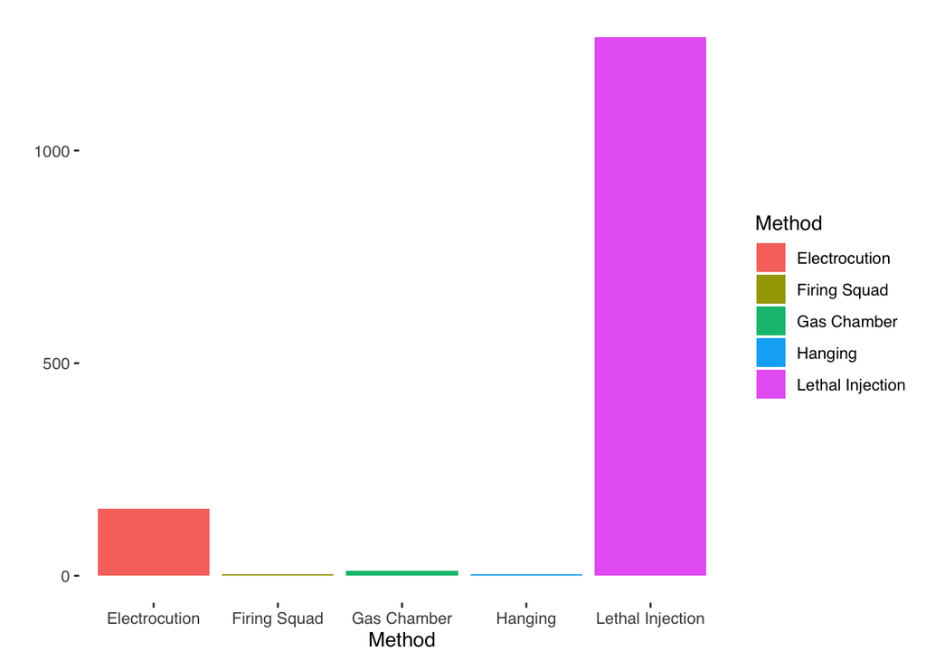

```r
qplot(Method, geom="bar", data=exData, fill=Method)
```

Judging from the above, it looks like two methods are by far the most common: electrocution and lethal injection. Let’s take a look at them in more detail.

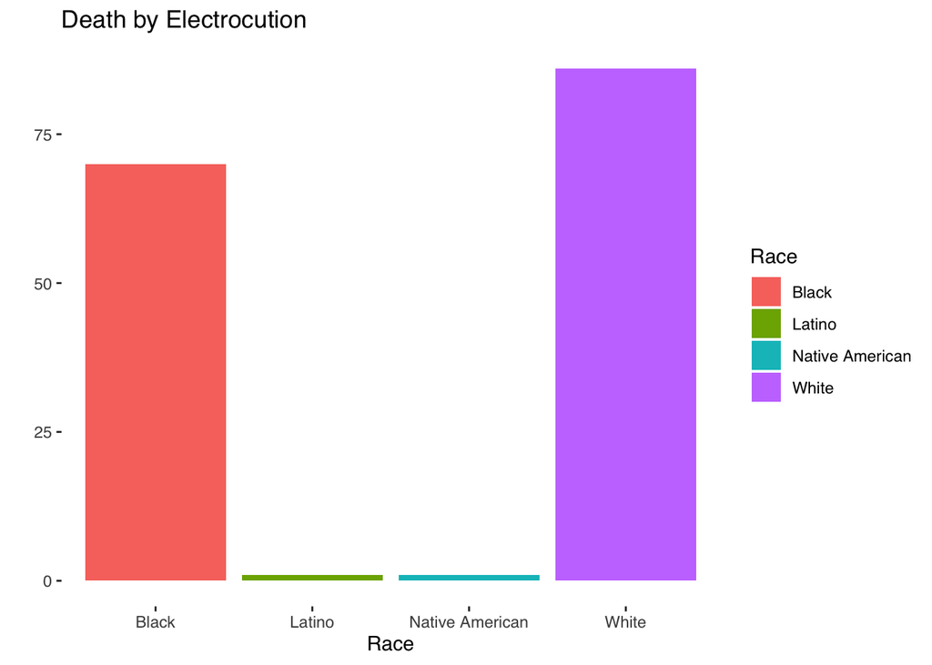

```r
#Let's do electrocution first.  Let's filter:

electricExecutions <- exData %>% filter(Method == "Electrocution")

qplot(Race, data = electricExecutions, fill=Race,
      main="Death by Electrocution")
```

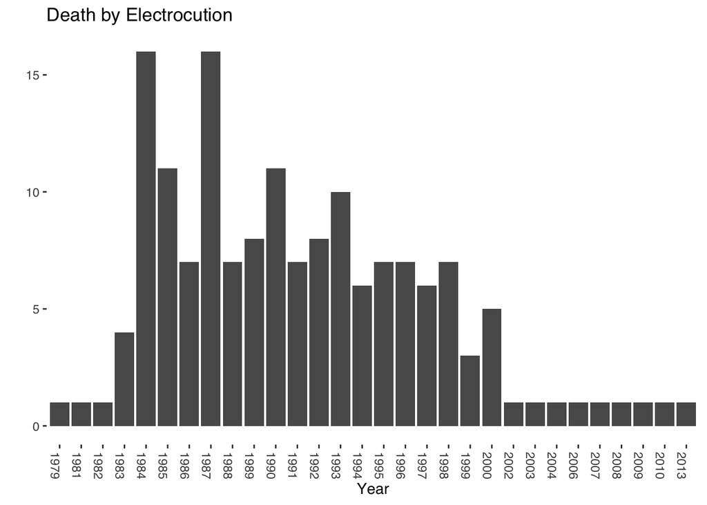

```r
qplot(Year, data=electricExecutions,
      main="Death by Electrocution")+angle_x_axis
```

Observations:

1. Looks like there’s almost parity between black and white prisoners who were electrocuted. Are black prisoners more likely to be electrocuted? We could do a little math to compare the proporiton here to the overall.
2. It’s clear the electrocution was used mostly in the 80s and 90s, tapering off to just one a year in the 2000s and one total for the years after 2010. What factors contributed to its rise and decline? Legislation? Technology? Public attitudes?

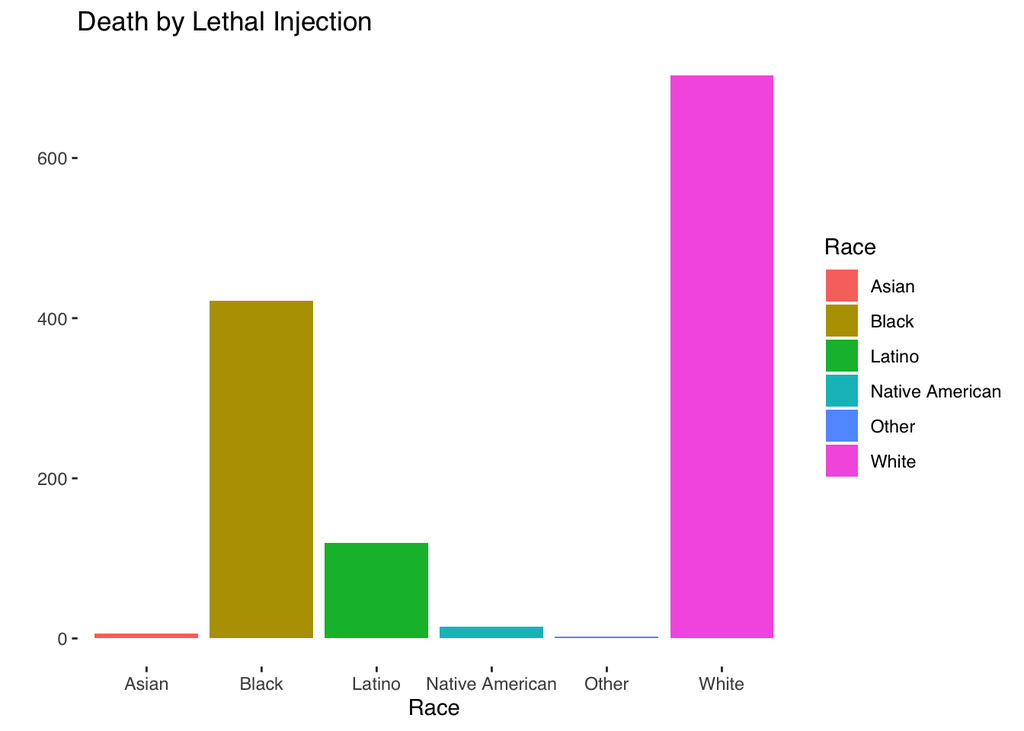

```r
#Let's do lethal injection next.  Let's filter:

injectedExecutions <- exData %>% filter(Method == "Lethal Injection")

qplot(Race, data = injectedExecutions, fill=Race,
      main="Death by Lethal Injection")
```

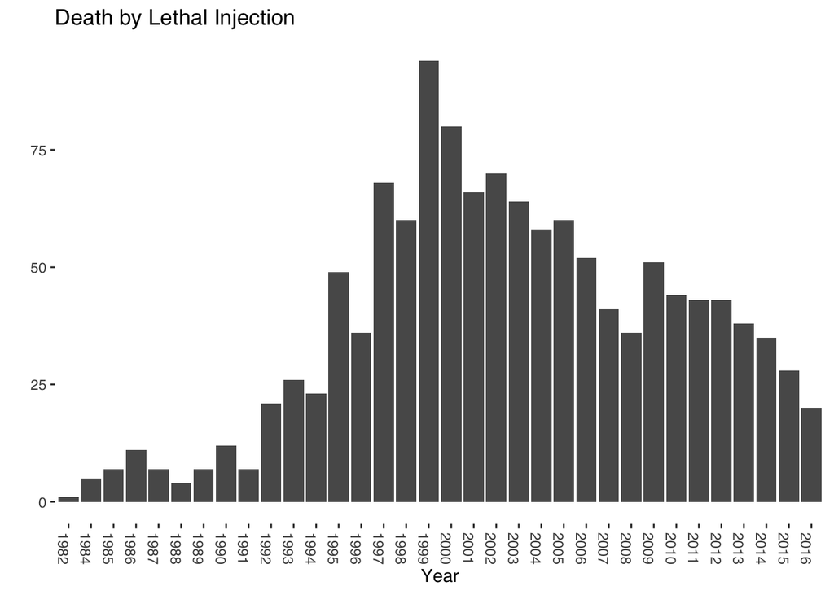

```r
qplot(Year, data=injectedExecutions,
      main="Death by Lethal Injection")+angle_x_axis
```

It seems like a clear trend is emerging: as the US trended away from electrocution in the 90s, it transitioned to execution by lethal injection. I also notice that latino americans have been executed by lethal injection; what factors might contribute?

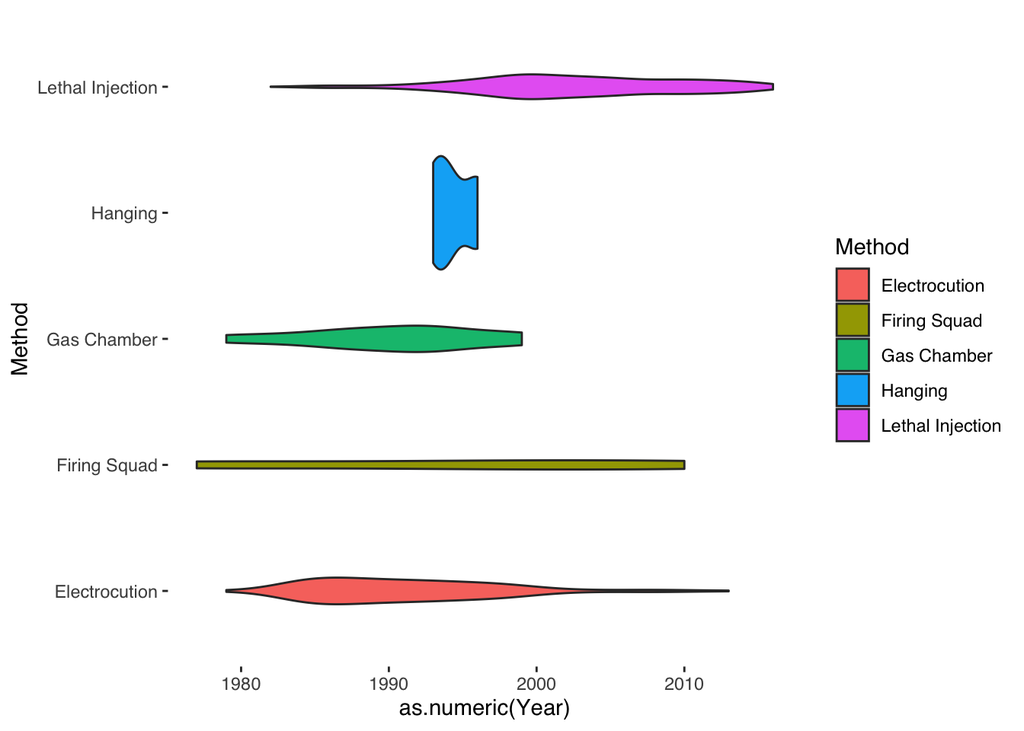

```r
qplot(Method, as.numeric(Year), geom="violin", data=exData, fill=Method)+
  coord_flip()
```

One last graph: let’s compare the the distribution of execution methods across states for our dirty dozen.

```r
dirtyMethodDistro <- dirtyDozen %>%
                       count(State, Method) %>%
                       group_by(State) %>%
                       mutate(prop=n/sum(n))
dirtyDozen %>% count(State, Method) %>% group_by(State) %>% mutate(prop=n/sum(n))
```

```
## # A tibble: 20 x 4
## # Groups:   State [12]
##    State Method               n   prop
##    <chr> <chr>            <int>  <dbl>
##  1 AL    Electrocution       24 0.414
##  2 AL    Lethal Injection    34 0.586
##  3 AR    Electrocution        1 0.0370
##  4 AR    Lethal Injection    26 0.963
##  5 AZ    Gas Chamber          2 0.0541
##  6 AZ    Lethal Injection    35 0.946
##  7 FL    Electrocution       44 0.478
##  8 FL    Lethal Injection    48 0.522
##  9 GA    Electrocution       23 0.333
## 10 GA    Lethal Injection    46 0.667
## 11 MO    Lethal Injection    87 1
## 12 NC    Gas Chamber          2 0.0465
## 13 NC    Lethal Injection    41 0.953
## 14 OH    Lethal Injection    53 1
## 15 OK    Lethal Injection   112 1
## 16 SC    Electrocution        7 0.163
## 17 SC    Lethal Injection    36 0.837
## 18 TX    Lethal Injection   538 1
## 19 VA    Electrocution       31 0.279
## 20 VA    Lethal Injection    80 0.721
```

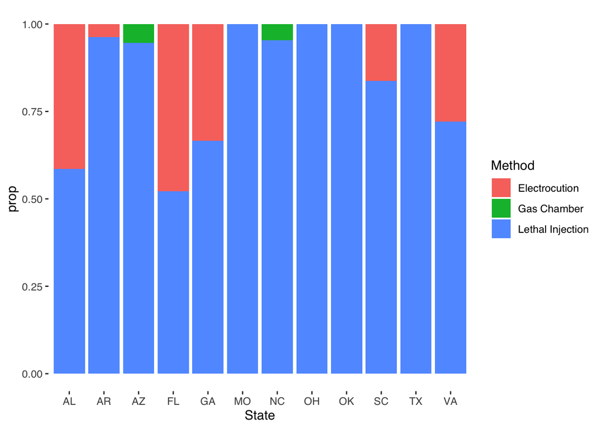

```r
qplot(State, prop, fill=Method, data=dirtyMethodDistro, geom="col")
```

It seems that, even amongs states with the highest numbers of executions, there is disagreement about whether or not electrocution should be used. Even Texas, slayer of men, has never used electrocution or gas!

## Their Victims

One issue when analyzing the victims: this dataset is not entirely “tidy”, as info about multiple homocides has been condensed into a single column. We can fix this, but it’ll require a little more *data wrangling* (yee haw!) than we’re ready for right now.

For the moment, let’s focus only on single homocides.

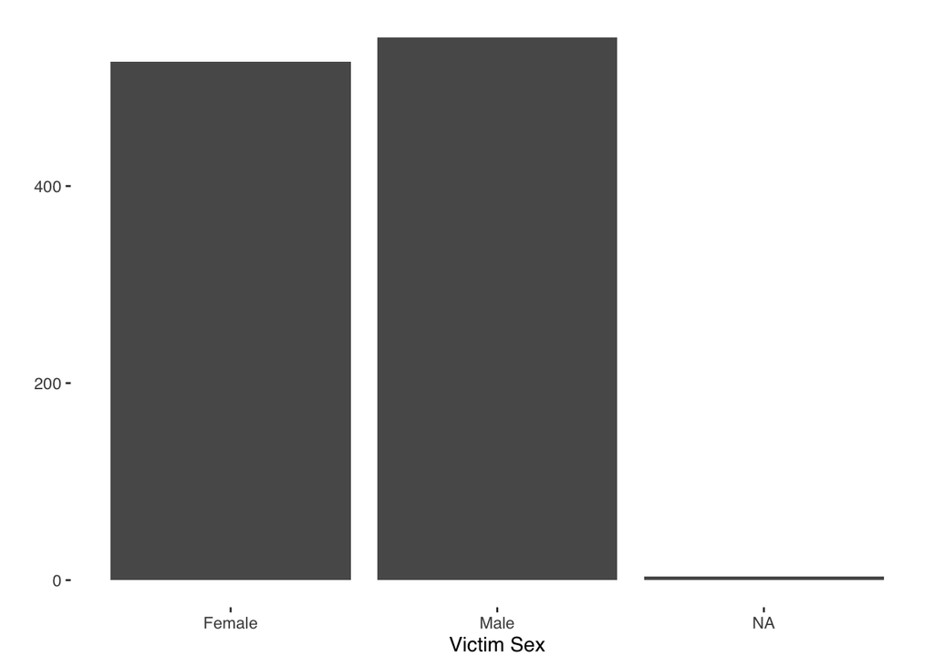

```r
singleHomo <- exData %>% filter(`Victim Count` == 1)


qplot(`Victim Sex`, data=singleHomo)
```

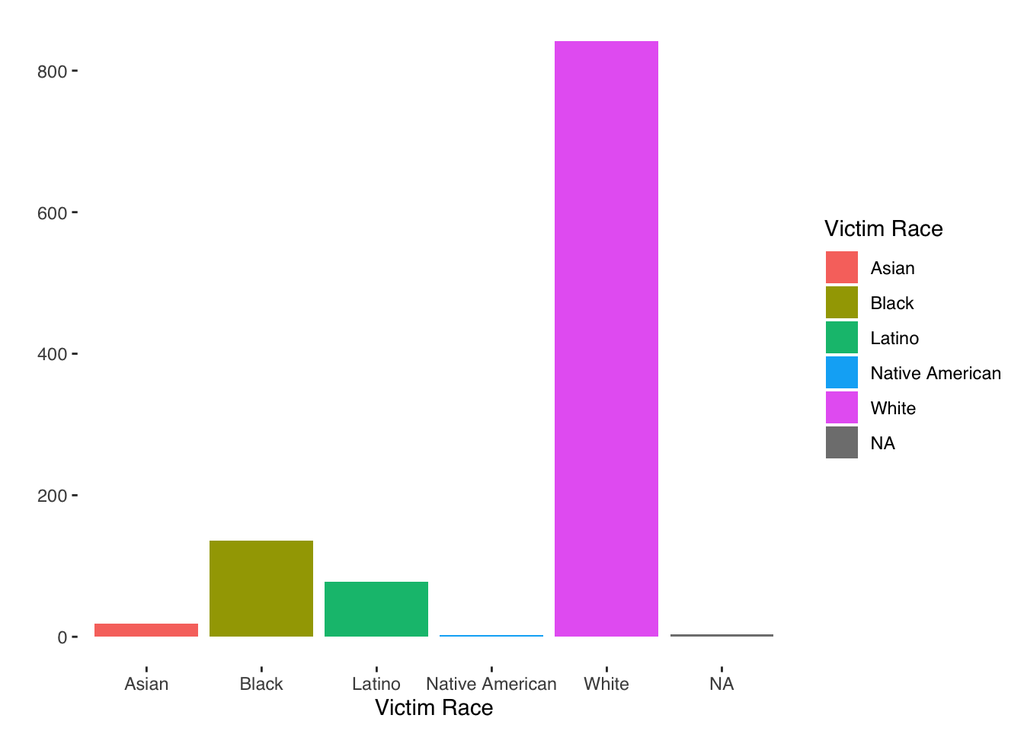

```r
qplot(`Victim Race`, data=singleHomo, fill=`Victim Race`)
```

Observations:

1. It seems that there’s a fairly equal gender split, overall, amongst the victims.
2. There were 1081 total victims, and 842 of them were white; that’s 77.8908418% of single homocide victims who are white. This is very close to the proportion of whites in the US during the years in question. Eyeballing the other categories, **it makes me suspect that race is not a factor when murderers select their victims**. Of course, this is at the national level; almost certainly individual criminals have a broad range of motivations.

## Conclusions and Recommendations

We’ve only scratched the surface of the dataset, but our preliminary observations have led us to a few conclusions and further questiosn:

1. What happened in the year 2000 that changed the growing trend of exections?
2. It seems that Black Americans are highly overrepresented in executions. If we could integrate demographic data across time and states, we’d be able to say more.
3. What the hell is going on in Texas? It seems like an entirely seperate study would be needed.
4. Oklahoma and Arizona stand out for executing native americans. What factors have contributed to this?